# Graded Novelty Enoding Task - 4 shapes version - judge difference

# Exclusions

We excluded 11 participants due to a high number of missed responses in the study phase (<= 10).

We excluded 6 participants due to low recognition rates (<= 20).

This left 42-42 participants in the analysis.

The identifiers are: 566_462, 565_459, 564_458, 562_456, 561_453, 560_451, 559_449, 557_435, 554_423, 551_407, 547_385, 544_371, 543_367, 540_343, 539_342, 536_324, 535_323, 534_308, 533_262, 532_259, 531_253, 530_240, 529_215, 528_214, 527_213, 526_212, 524_210, 523_208, 522_207, 520_205, 518_204, 519_203, 517_202, 516_200, 515_199, 511_193, 508_192, 510_191, 504_190, 505_189, 507_187, 503_180

# Study phase

Participants make a judgement of the difference between a prototype and a novel picture.

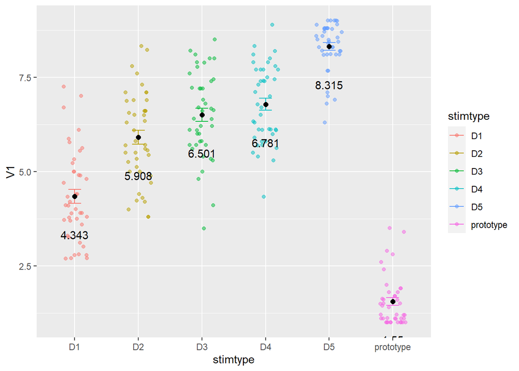

# Test phase

Test phase was the same as before: participants see the novel pictures from the study phase with distractors from the same categories. They signal if they think the picture is an old one from the study phase, or a novel distractor.

```
##
##  Paired t-test
##
## data:  a and b
## t = 0.83958, df = 209, p-value = 0.4021
## alternative hypothesis: true difference in means is not equal to 0
## 95 percent confidence interval:
##  -0.1540642  0.3826356
## sample estimates:
## mean of the differences
##               0.1142857
```

```
##
## Cohen's d
##
## d estimate: 0.05455349 (negligible)
## 95 percent confidence interval:
##       lower       upper
## -0.07326452  0.18237150
```

```
##
##  Shapiro-Wilk normality test
##
## data:  d
## W = 0.97268, p-value = 0.000421
```

```
## [1] "Correct recognition for familiars in test"
```

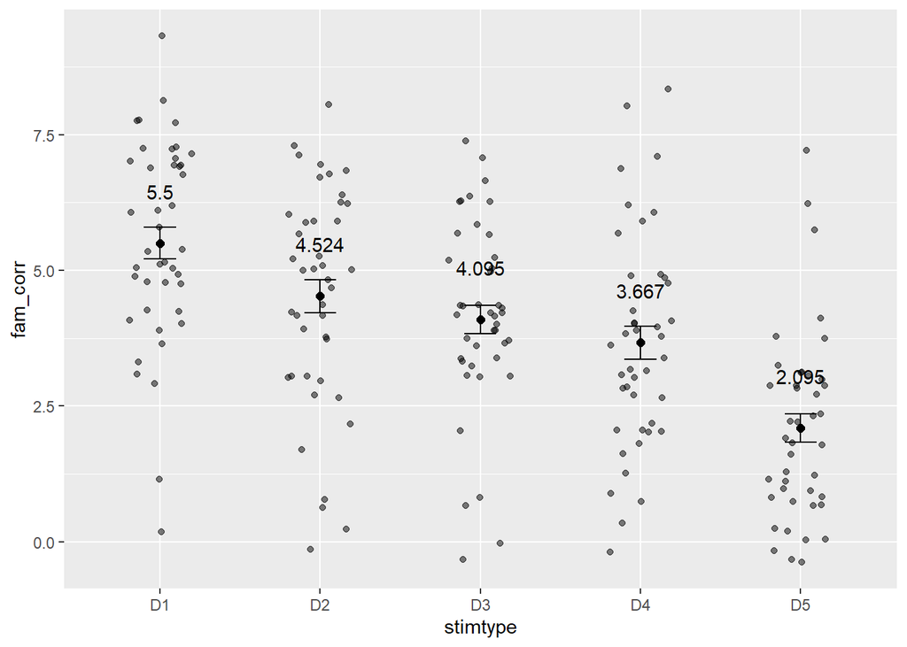

```
## [1] "False alarm for novels in test"
```

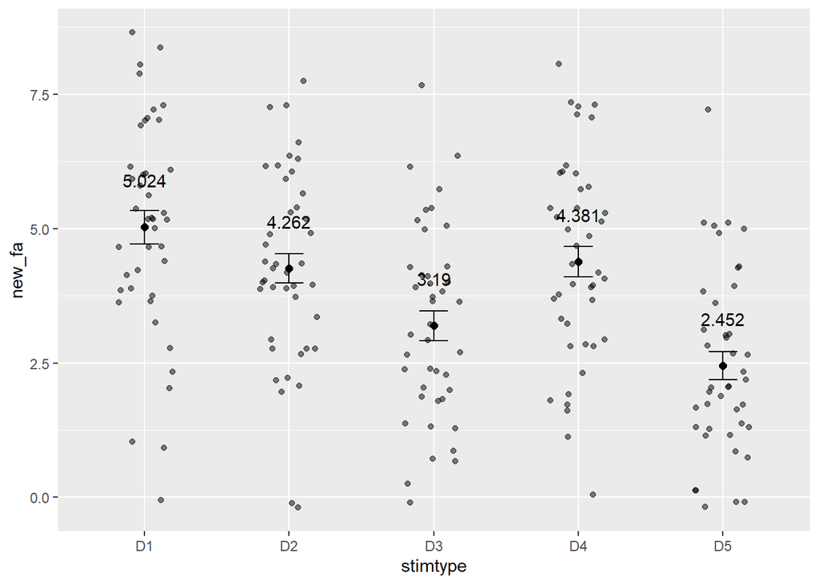

```
## [1] "ANOVA with correct recognition minus false alarm or miss by fam/nov"
```

```
## Anova Table (Type 3 tests)
##
## Response: CorrectedRecognitions
##     Effect           df  MSE       F  ges p.value
## 1 stimtype 3.65, 149.68 3.84 5.06 ** .087    .001
## ---
## Signif. codes:  0 '***' 0.001 '**' 0.01 '*' 0.05 '+' 0.1 ' ' 1
##
## Sphericity correction method: GG
```

```
##  contrast estimate    SE  df t.ratio p.value
##  D1 - D2     0.214 0.408 164  0.525  0.9847
##  D1 - D3    -0.429 0.408 164 -1.049  0.8318
##  D1 - D4     1.190 0.408 164  2.915  0.0326
##  D1 - D5     0.833 0.408 164  2.041  0.2515
##  D2 - D3    -0.643 0.408 164 -1.574  0.5161
##  D2 - D4     0.976 0.408 164  2.390  0.1231
##  D2 - D5     0.619 0.408 164  1.516  0.5537
##  D3 - D4     1.619 0.408 164  3.965  0.0010
##  D3 - D5     1.262 0.408 164  3.090  0.0197
##  D4 - D5    -0.357 0.408 164 -0.875  0.9059
##
## P value adjustment: tukey method for comparing a family of 5 estimates
```

```
##  contrast  estimate    SE  df t.ratio p.value
##  linear       -2.64 0.913 164 -2.894  0.0043
##  quadratic    -1.12 1.080 164 -1.036  0.3019
##  cubic         1.12 0.913 164  1.225  0.2222
##  quartic       7.36 2.416 164  3.045  0.0027
```

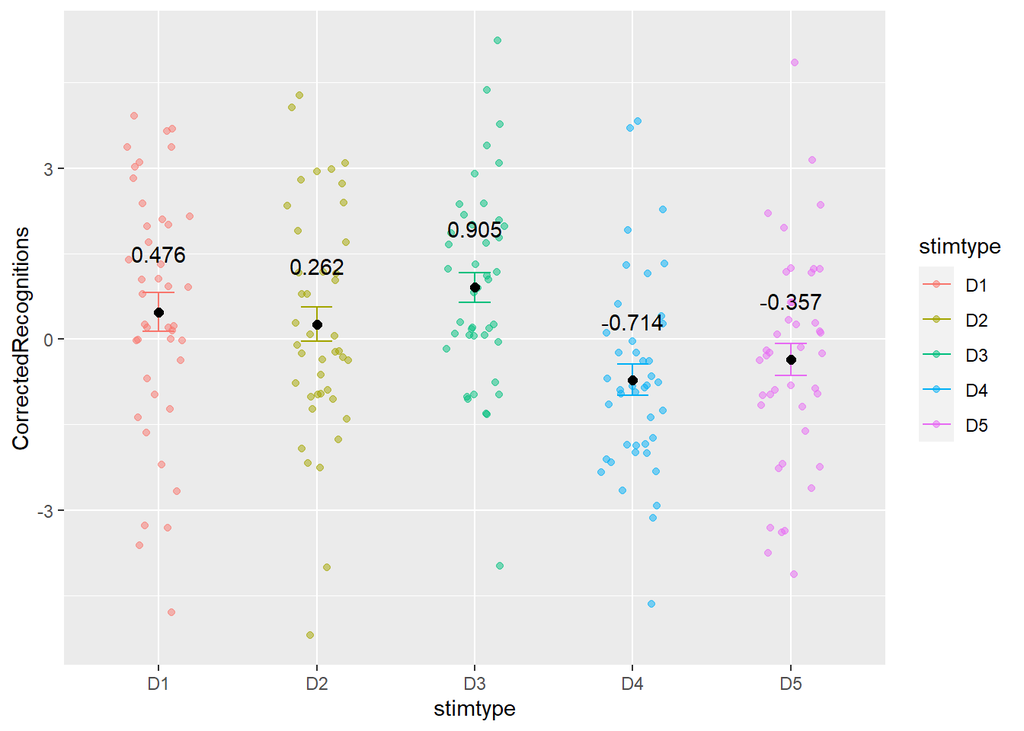

```
## [1] "ANOVA with correct rejection minus false alarm or miss by fam/nov"
```

```
## Anova Table (Type 3 tests)
##
## Response: CorrectedRejections
##     Effect           df  MSE        F  ges p.value
## 1 stimtype 3.69, 151.30 4.40 5.18 *** .093   <.001
## ---
## Signif. codes:  0 '***' 0.001 '**' 0.01 '*' 0.05 '+' 0.1 ' ' 1
##
## Sphericity correction method: GG
```

```
##  contrast estimate   SE  df t.ratio p.value
##  D1 - D2     0.310 0.44 164  0.704  0.9553
##  D1 - D3    -0.429 0.44 164 -0.975  0.8662
##  D1 - D4     1.333 0.44 164  3.033  0.0233
##  D1 - D5     0.929 0.44 164  2.112  0.2198
##  D2 - D3    -0.738 0.44 164 -1.679  0.4498
##  D2 - D4     1.024 0.44 164  2.329  0.1410
##  D2 - D5     0.619 0.44 164  1.408  0.6233
##  D3 - D4     1.762 0.44 164  4.008  0.0009
##  D3 - D5     1.357 0.44 164  3.087  0.0198
##  D4 - D5    -0.405 0.44 164 -0.921  0.8886
##
## P value adjustment: tukey method for comparing a family of 5 estimates
```

```
##  contrast  estimate    SE  df t.ratio p.value
##  linear       -2.88 0.983 164 -2.931  0.0039
##  quadratic    -1.07 1.163 164 -0.921  0.3583
##  cubic         1.12 0.983 164  1.138  0.2566
##  quartic       8.21 2.601 164  3.158  0.0019
```

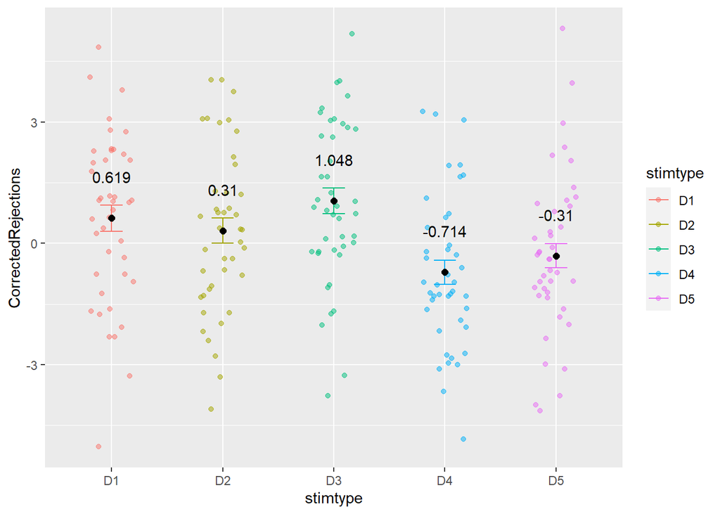

```
## [1] "ANOVA with corrected differentiation score by category ((crecog-fa)+(creject-fa))"
```

```
## Anova Table (Type 3 tests)
##
## Response: OCCategorizations
##     Effect           df   MSE        F  ges p.value
## 1 stimtype 3.73, 152.84 15.02 5.52 *** .097   <.001
## ---
## Signif. codes:  0 '***' 0.001 '**' 0.01 '*' 0.05 '+' 0.1 ' ' 1
##
## Sphericity correction method: GG
```

```
##  contrast estimate    SE  df t.ratio p.value
##  D1 - D2     0.524 0.816 164  0.642  0.9680
##  D1 - D3    -0.857 0.816 164 -1.050  0.8316
##  D1 - D4     2.524 0.816 164  3.091  0.0196
##  D1 - D5     1.762 0.816 164  2.158  0.2010
##  D2 - D3    -1.381 0.816 164 -1.692  0.4420
##  D2 - D4     2.000 0.816 164  2.450  0.1075
##  D2 - D5     1.238 0.816 164  1.517  0.5532
##  D3 - D4     3.381 0.816 164  4.141  0.0005
##  D3 - D5     2.619 0.816 164  3.208  0.0137
##  D4 - D5    -0.762 0.816 164 -0.933  0.8836
##
## P value adjustment: tukey method for comparing a family of 5 estimates
```

```
##  contrast  estimate   SE  df t.ratio p.value
##  linear       -5.52 1.83 164 -3.026  0.0029
##  quadratic    -2.19 2.16 164 -1.014  0.3120
##  cubic         2.24 1.83 164  1.226  0.2219
##  quartic      15.57 4.83 164  3.224  0.0015
```

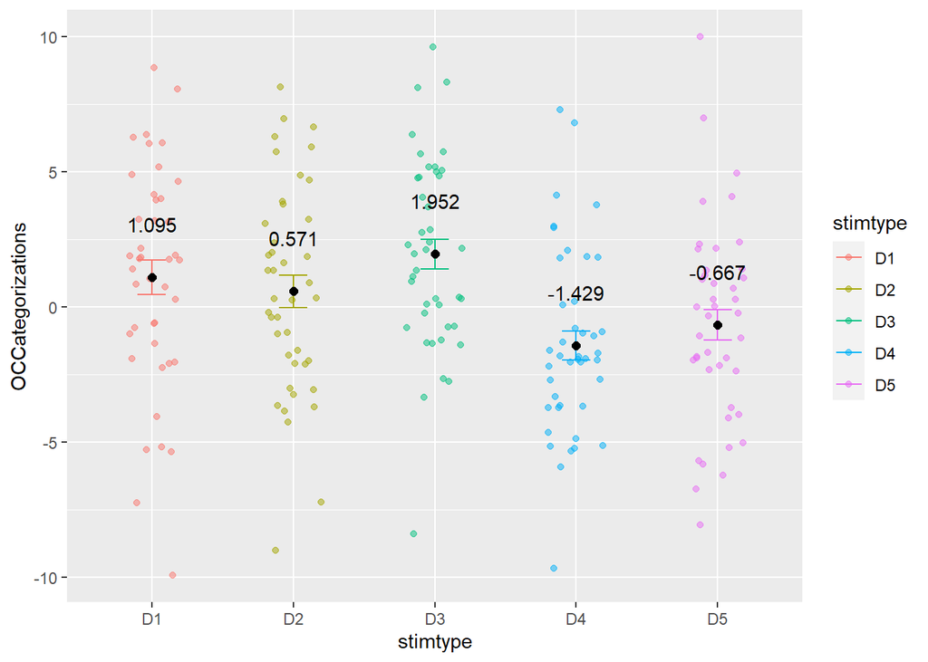

# Mixed models

## Test phase

### Models #1

```
## Generalized linear mixed model fit by maximum likelihood (Laplace
##   Approximation) [glmerMod]
##  Family: binomial  ( logit )
## Formula: rt_resp ~ stimtype * test_quality + (1 | workerId)
##    Data: tdlmm
##
##      AIC      BIC   logLik deviance df.resid
##   4972.2   5041.3  -2475.1   4950.2     3935
##
## Scaled residuals:
##     Min      1Q  Median      3Q     Max
## -4.8620 -0.9360  0.4677  0.8233  1.7506
##
## Random effects:
##  Groups   Name        Variance Std.Dev.
##  workerId (Intercept) 0.4686   0.6846
## Number of obs: 3946, groups:  workerId, 42
##
## Fixed effects:
##                            Estimate Std. Error z value Pr(>|z|)
## (Intercept)                 -0.3729     0.1511  -2.467 0.013620 *
## stimtypeD2                   0.5088     0.1503   3.386 0.000709 ***
## stimtypeD3                   0.6489     0.1514   4.287 1.81e-05 ***
## stimtypeD4                   0.8611     0.1523   5.654 1.57e-08 ***
## stimtypeD5                   1.7344     0.1644  10.547  < 2e-16 ***
## test_qualitynew              0.2628     0.1506   1.745 0.081063 .
## stimtypeD2:test_qualitynew  -0.1469     0.2111  -0.696 0.486451
## stimtypeD3:test_qualitynew   0.2076     0.2144   0.968 0.333063
## stimtypeD4:test_qualitynew  -0.6026     0.2131  -2.828 0.004690 **
## stimtypeD5:test_qualitynew  -0.4609     0.2274  -2.026 0.042726 *
## ---
## Signif. codes:  0 '***' 0.001 '**' 0.01 '*' 0.05 '.' 0.1 ' ' 1
##
## Correlation of Fixed Effects:
##             (Intr) stmtD2 stmtD3 stmtD4 stmtD5 tst_ql stD2:_ stD3:_ stD4:_
## stimtypeD2  -0.512
## stimtypeD3  -0.508  0.512
## stimtypeD4  -0.504  0.510  0.506
## stimtypeD5  -0.467  0.473  0.470  0.468
## test_qltynw -0.510  0.514  0.511  0.507  0.471
## stmtypD2:t_  0.364 -0.711 -0.364 -0.362 -0.336 -0.714
## stmtypD3:t_  0.359 -0.361 -0.705 -0.356 -0.330 -0.702  0.501
## stmtypD4:t_  0.361 -0.364 -0.361 -0.714 -0.334 -0.707  0.505  0.496
## stmtypD5:t_  0.338 -0.341 -0.338 -0.336 -0.720 -0.662  0.473  0.465  0.468
```

```
## Package `effects` is not available, but needed for `ggeffect()`. Either install package `effects`, or use `ggpredict()`. Calling `ggpredict()` now.FALSE
```

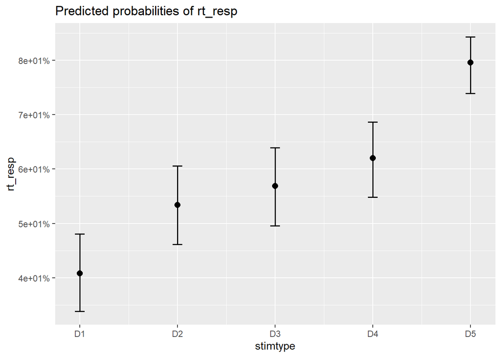

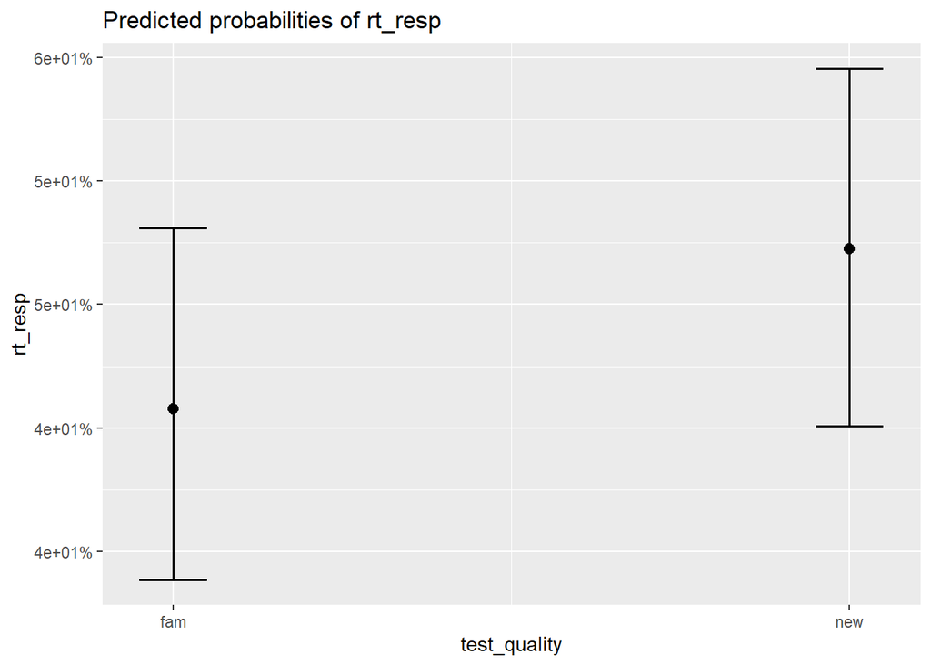

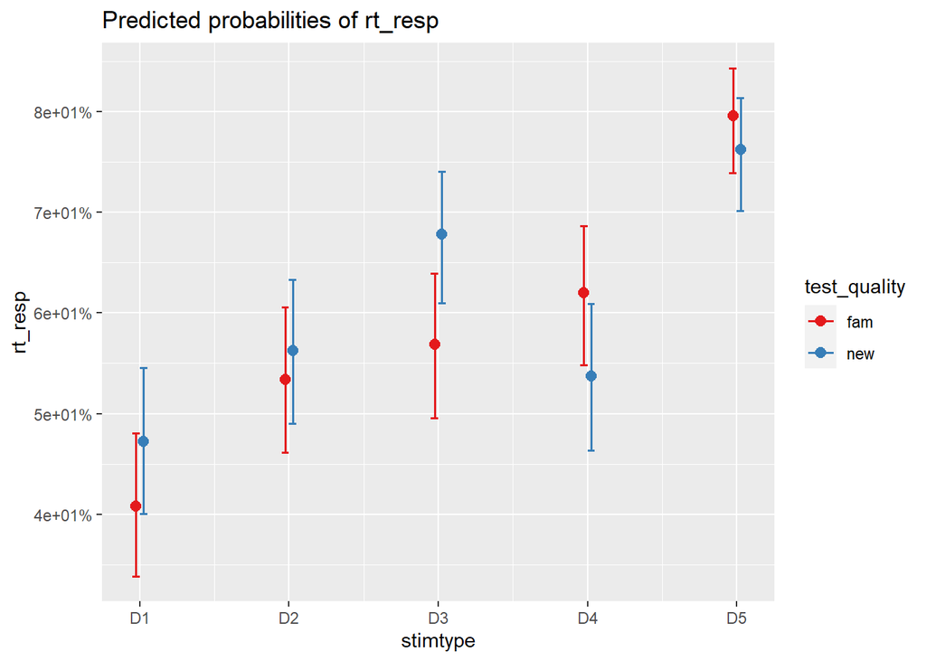

```
## Generalized linear mixed model fit by maximum likelihood (Laplace
##   Approximation) [glmerMod]
##  Family: binomial  ( logit )
## Formula: rt_resp ~ DTF * test_quality + (1 | workerId)
##    Data: tdlmm
##
##      AIC      BIC   logLik deviance df.resid
##   5015.1   5046.5  -2502.6   5005.1     3941
##
## Scaled residuals:
##     Min      1Q  Median      3Q     Max
## -5.1519 -0.9529  0.4812  0.8406  1.6212
##
## Random effects:
##  Groups   Name        Variance Std.Dev.
##  workerId (Intercept) 0.4558   0.6752
## Number of obs: 3946, groups:  workerId, 42
##
## Fixed effects:
##                     Estimate Std. Error z value Pr(>|z|)
## (Intercept)         -0.47874    0.13887  -3.447 0.000566 ***
## DTF                  0.12400    0.01203  10.309  < 2e-16 ***
## test_qualitynew      0.39359    0.12878   3.056 0.002241 **
## DTF:test_qualitynew -0.04723    0.01689  -2.797 0.005163 **
## ---
## Signif. codes:  0 '***' 0.001 '**' 0.01 '*' 0.05 '.' 0.1 ' ' 1
##
## Correlation of Fixed Effects:
##             (Intr) DTF    tst_ql
## DTF         -0.556
## test_qltynw -0.468  0.601
## DTF:tst_qlt  0.396 -0.710 -0.848
```

```
## Package `effects` is not available, but needed for `ggeffect()`. Either install package `effects`, or use `ggpredict()`. Calling `ggpredict()` now.FALSE
```

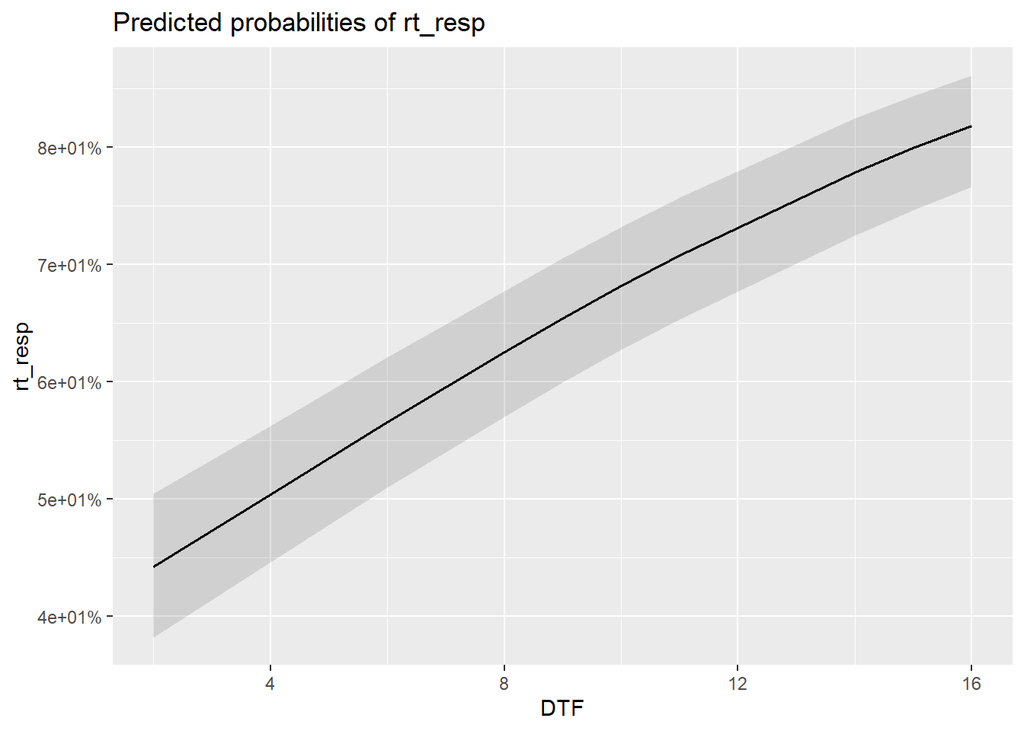

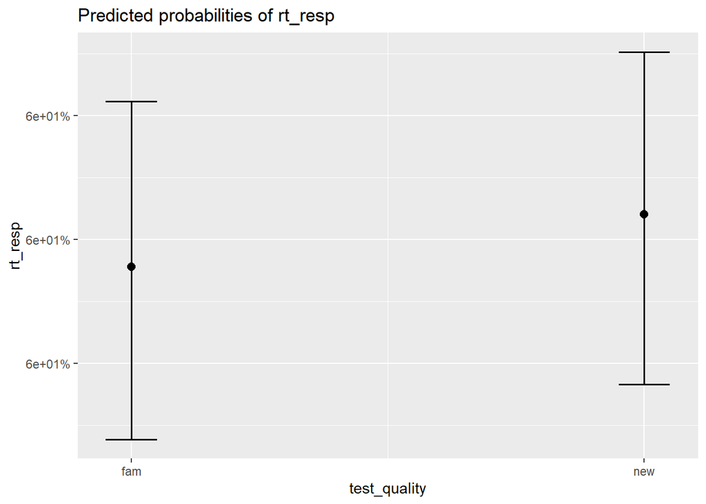

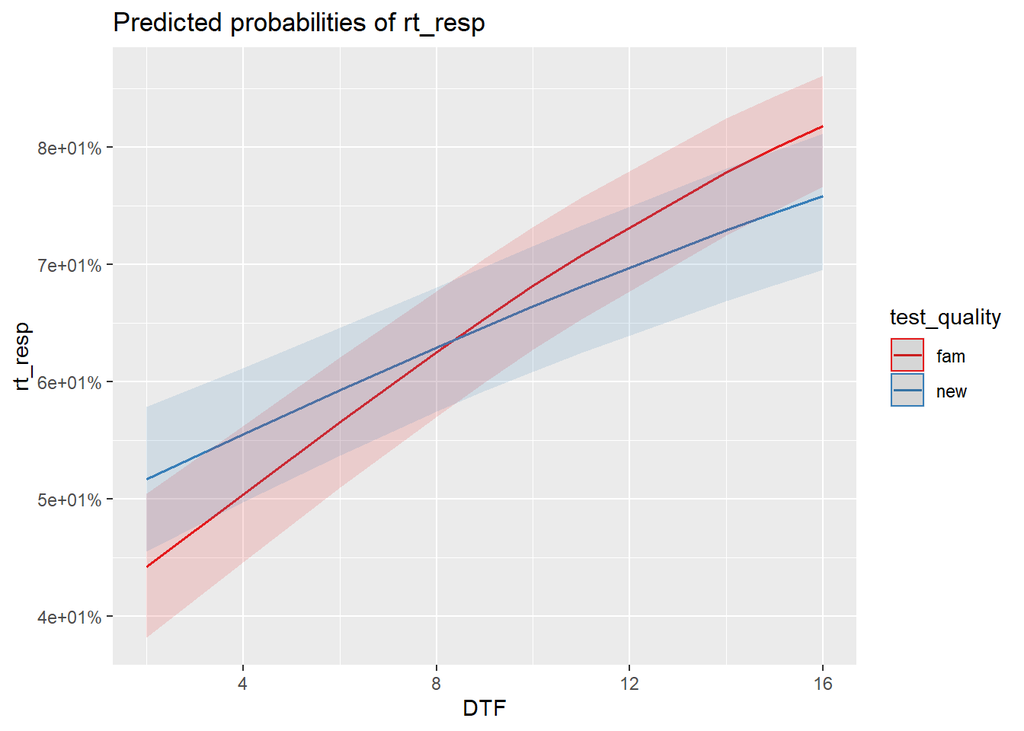

```
## Generalized linear mixed model fit by maximum likelihood (Laplace
##   Approximation) [glmerMod]
##  Family: binomial  ( logit )
## Formula: rt_resp ~ DTAF * test_quality + (1 | workerId)
##    Data: tdlmm
##
##      AIC      BIC   logLik deviance df.resid
##   5023.7   5055.1  -2506.9   5013.7     3941
##
## Scaled residuals:
##     Min      1Q  Median      3Q     Max
## -4.4784 -0.9646  0.4933  0.8401  1.6944
##
## Random effects:
##  Groups   Name        Variance Std.Dev.
##  workerId (Intercept) 0.4556   0.675
## Number of obs: 3946, groups:  workerId, 42
##
## Fixed effects:
##                      Estimate Std. Error z value Pr(>|z|)
## (Intercept)          -3.71938    0.43555  -8.539   <2e-16 ***
## DTAF                  0.30172    0.03130   9.639   <2e-16 ***
## test_qualitynew       1.17409    0.59443   1.975   0.0483 *
## DTAF:test_qualitynew -0.08254    0.04387  -1.881   0.0599 .
## ---
## Signif. codes:  0 '***' 0.001 '**' 0.01 '*' 0.05 '.' 0.1 ' ' 1
##
## Correlation of Fixed Effects:
##             (Intr) DTAF   tst_ql
## DTAF        -0.964
## test_qltynw -0.689  0.705
## DTAF:tst_ql  0.686 -0.711 -0.993
```

```
## Package `effects` is not available, but needed for `ggeffect()`. Either install package `effects`, or use `ggpredict()`. Calling `ggpredict()` now.FALSE
```

```
## Data were 'prettified'. Consider using `terms="DTAF [all]"` to get smooth plots.
```

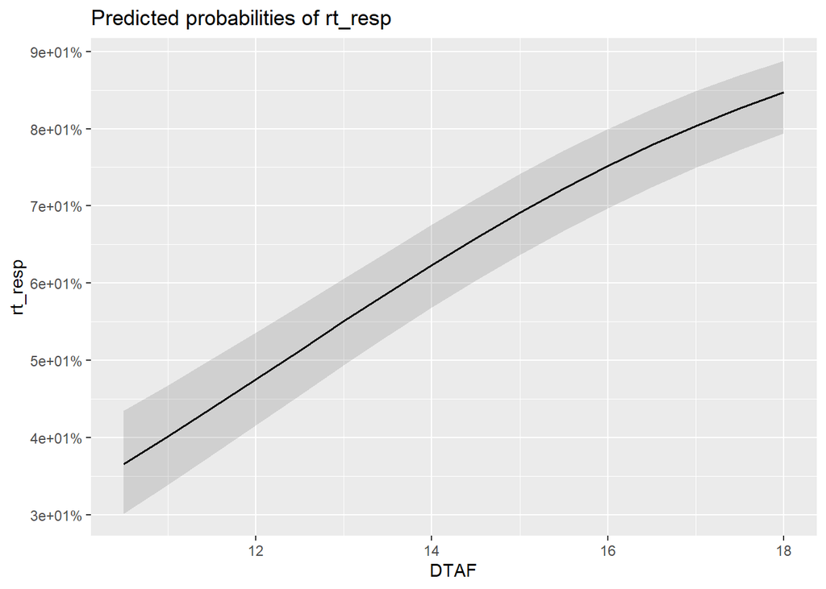

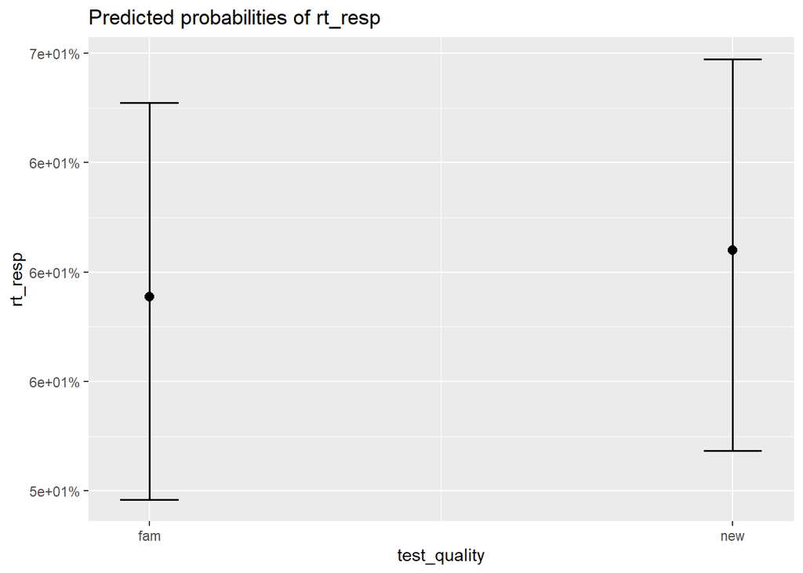

```
## Data were 'prettified'. Consider using `terms="DTAF [all]"` to get smooth plots.
```

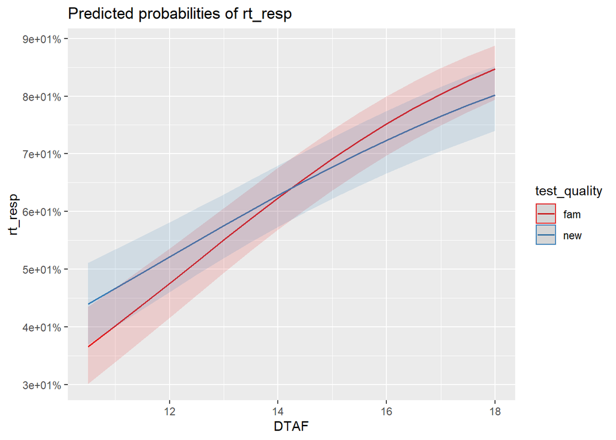

```
## Generalized linear mixed model fit by maximum likelihood (Laplace
##   Approximation) [glmerMod]
##  Family: binomial  ( logit )
## Formula: rt_resp ~ DTAN * test_quality + (1 | workerId)
##    Data: tdlmm
##
##      AIC      BIC   logLik deviance df.resid
##   5109.4   5140.8  -2549.7   5099.4     3941
##
## Scaled residuals:
##     Min      1Q  Median      3Q     Max
## -3.2362 -1.0001  0.5434  0.8577  1.5728
##
## Random effects:
##  Groups   Name        Variance Std.Dev.
##  workerId (Intercept) 0.4405   0.6637
## Number of obs: 3946, groups:  workerId, 42
##
## Fixed effects:
##                      Estimate Std. Error z value Pr(>|z|)
## (Intercept)          -3.54127    0.65015  -5.447 5.13e-08 ***
## DTAN                  0.28901    0.04761   6.070 1.28e-09 ***
## test_qualitynew       0.59812    0.89271   0.670    0.503
## DTAN:test_qualitynew -0.03948    0.06615  -0.597    0.551
## ---
## Signif. codes:  0 '***' 0.001 '**' 0.01 '*' 0.05 '.' 0.1 ' ' 1
##
## Correlation of Fixed Effects:
##             (Intr) DTAN   tst_ql
## DTAN        -0.985
## test_qltynw -0.709  0.716
## DTAN:tst_ql  0.708 -0.718 -0.997
## convergence code: 0
## Model failed to converge with max|grad| = 0.00521384 (tol = 0.002, component 1)
```

```
## Package `effects` is not available, but needed for `ggeffect()`. Either install package `effects`, or use `ggpredict()`. Calling `ggpredict()` now.FALSE
```

```
## Data were 'prettified'. Consider using `terms="DTAN [all]"` to get smooth plots.
```

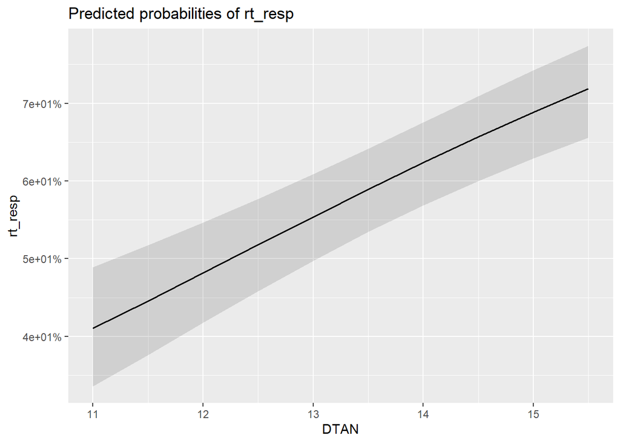

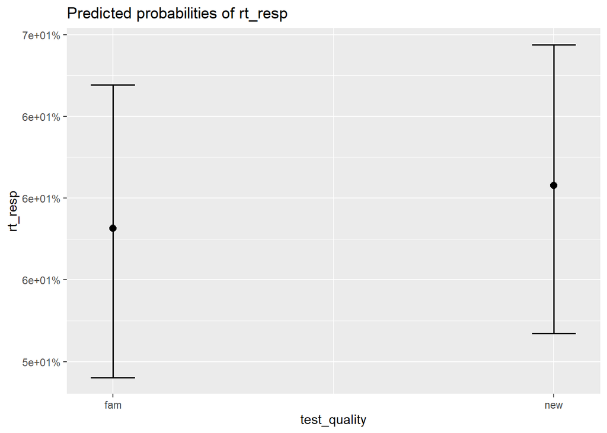

```
## Data were 'prettified'. Consider using `terms="DTAN [all]"` to get smooth plots.
```

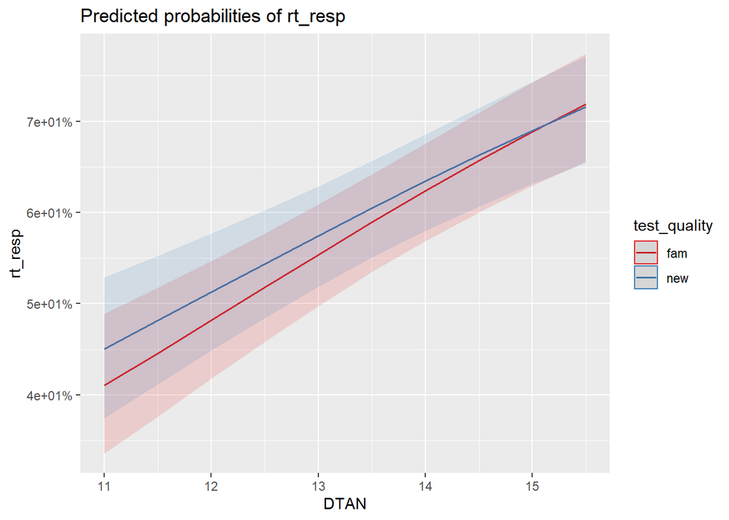

```
## Generalized linear mixed model fit by maximum likelihood (Laplace
##   Approximation) [glmerMod]
##  Family: binomial  ( logit )
## Formula: rt_resp ~ DTN_byPhase * test_quality + (1 | workerId)
##    Data: tdlmm
##
##      AIC      BIC   logLik deviance df.resid
##   5116.3   5147.7  -2553.1   5106.3     3941
##
## Scaled residuals:
##     Min      1Q  Median      3Q     Max
## -3.3514 -1.0018  0.5413  0.8594  1.5065
##
## Random effects:
##  Groups   Name        Variance Std.Dev.
##  workerId (Intercept) 0.439    0.6626
## Number of obs: 3946, groups:  workerId, 42
##
## Fixed effects:
##                             Estimate Std. Error z value Pr(>|z|)
## (Intercept)                 -3.04102    0.61443  -4.949 7.45e-07 ***
## DTN_byPhase                  0.24248    0.04323   5.609 2.04e-08 ***
## test_qualitynew              0.25690    0.85541   0.300    0.764
## DTN_byPhase:test_qualitynew -0.01359    0.06100  -0.223    0.824
## ---
## Signif. codes:  0 '***' 0.001 '**' 0.01 '*' 0.05 '.' 0.1 ' ' 1
##
## Correlation of Fixed Effects:
##             (Intr) DTN_bP tst_ql
## DTN_byPhase -0.983
## test_qltynw -0.698  0.705
## DTN_byPhs:_  0.696 -0.707 -0.997
## convergence code: 0
## Model failed to converge with max|grad| = 0.0026114 (tol = 0.002, component 1)
```

```
## Package `effects` is not available, but needed for `ggeffect()`. Either install package `effects`, or use `ggpredict()`. Calling `ggpredict()` now.FALSE
```

```
## Data were 'prettified'. Consider using `terms="DTN_byPhase [all]"` to get smooth plots.
```

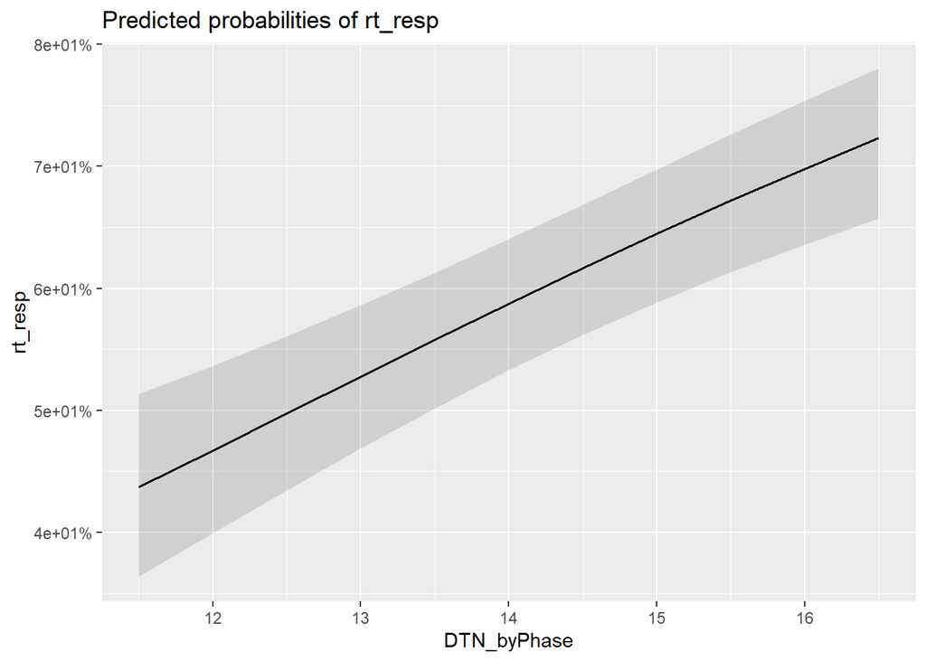

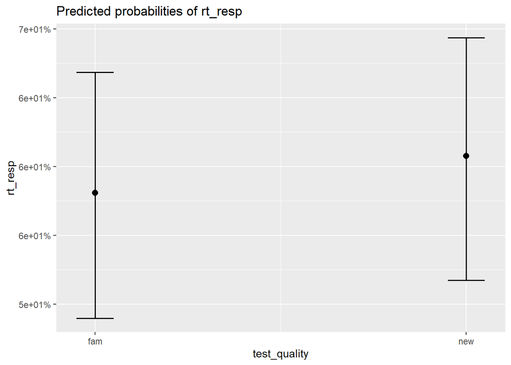

```
## Data were 'prettified'. Consider using `terms="DTN_byPhase [all]"` to get smooth plots.
```

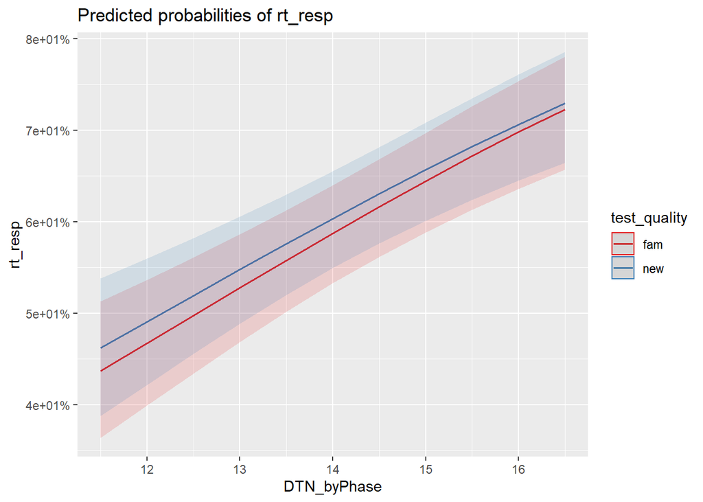

|  | rt_resp |  |  |  | rt_resp |  |  |  | rt_resp |  |  |  | rt_resp |  |  |  | rt_resp |  |  |  |
| --- | --- | --- | --- | --- | --- | --- | --- | --- | --- | --- | --- | --- | --- | --- | --- | --- | --- | --- | --- | --- |
| Predictors | Log-Odds | std. Error | CI | p | Log-Odds | std. Error | CI | p | Log-Odds | std. Error | CI | p | Log-Odds | std. Error | CI | p | Log-Odds | std. Error | CI | p |
| (Intercept) | -0.37 | 0.15 | -0.67 – -0.08 | **0.014** | -0.48 | 0.14 | -0.75 – -0.21 | **0.001** | -3.72 | 0.44 | -4.57 – -2.87 | **<0.001** | -3.54 | 0.65 | -4.82 – -2.27 | **<0.001** | -3.04 | 0.61 | -4.25 – -1.84 | **<0.001** |
| stimtype [D2] | 0.51 | 0.15 | 0.21 – 0.80 | **0.001** |  |  |  |  |  |  |  |  |  |  |  |  |  |  |  |  |
| stimtype [D3] | 0.65 | 0.15 | 0.35 – 0.95 | **<0.001** |  |  |  |  |  |  |  |  |  |  |  |  |  |  |  |  |
| stimtype [D4] | 0.86 | 0.15 | 0.56 – 1.16 | **<0.001** |  |  |  |  |  |  |  |  |  |  |  |  |  |  |  |  |
| stimtype [D5] | 1.73 | 0.16 | 1.41 – 2.06 | **<0.001** |  |  |  |  |  |  |  |  |  |  |  |  |  |  |  |  |
| test_quality [new] | 0.26 | 0.15 | -0.03 – 0.56 | 0.081 | 0.39 | 0.13 | 0.14 – 0.65 | **0.002** | 1.17 | 0.59 | 0.01 – 2.34 | **0.048** | 0.60 | 0.89 | -1.15 – 2.35 | 0.503 | 0.26 | 0.86 | -1.42 – 1.93 | 0.764 |
| stimtype [D2] * test_quality [new] | -0.15 | 0.21 | -0.56 – 0.27 | 0.486 |  |  |  |  |  |  |  |  |  |  |  |  |  |  |  |  |
| stimtype [D3] * test_quality [new] | 0.21 | 0.21 | -0.21 – 0.63 | 0.333 |  |  |  |  |  |  |  |  |  |  |  |  |  |  |  |  |
| stimtype [D4] * test_quality [new] | -0.60 | 0.21 | -1.02 – -0.18 | **0.005** |  |  |  |  |  |  |  |  |  |  |  |  |  |  |  |  |
| stimtype [D5] * test_quality [new] | -0.46 | 0.23 | -0.91 – -0.02 | **0.043** |  |  |  |  |  |  |  |  |  |  |  |  |  |  |  |  |
| DTF |  |  |  |  | 0.12 | 0.01 | 0.10 – 0.15 | **<0.001** |  |  |  |  |  |  |  |  |  |  |  |  |
| DTF * test_quality [new] |  |  |  |  | -0.05 | 0.02 | -0.08 – -0.01 | **0.005** |  |  |  |  |  |  |  |  |  |  |  |  |
| DTAF |  |  |  |  |  |  |  |  | 0.30 | 0.03 | 0.24 – 0.36 | **<0.001** |  |  |  |  |  |  |  |  |
| DTAF * test_quality [new] |  |  |  |  |  |  |  |  | -0.08 | 0.04 | -0.17 – 0.00 | 0.060 |  |  |  |  |  |  |  |  |
| DTAN |  |  |  |  |  |  |  |  |  |  |  |  | 0.29 | 0.05 | 0.20 – 0.38 | **<0.001** |  |  |  |  |
| DTAN * test_quality [new] |  |  |  |  |  |  |  |  |  |  |  |  | -0.04 | 0.07 | -0.17 – 0.09 | 0.551 |  |  |  |  |
| DTN_byPhase |  |  |  |  |  |  |  |  |  |  |  |  |  |  |  |  | 0.24 | 0.04 | 0.16 – 0.33 | **<0.001** |
| DTN_byPhase * test_quality [new] |  |  |  |  |  |  |  |  |  |  |  |  |  |  |  |  | -0.01 | 0.06 | -0.13 – 0.11 | 0.824 |
| Random Effects |  |  |  |  |  |  |  |  |  |  |  |  |  |  |  |  |  |  |  |  |
| σ<sup>2</sup> | 3.29 |  |  |  | 3.29 |  |  |  | 3.29 |  |  |  | 3.29 |  |  |  | 3.29 |  |  |  |
| τ<sub>00</sub> | 0.47 <sub>workerId</sub> |  |  |  | 0.46 <sub>workerId</sub> |  |  |  | 0.46 <sub>workerId</sub> |  |  |  | 0.44 <sub>workerId</sub> |  |  |  | 0.44 <sub>workerId</sub> |  |  |  |
| ICC | 0.12 |  |  |  | 0.12 |  |  |  | 0.12 |  |  |  | 0.12 |  |  |  | 0.12 |  |  |  |
| N | 42 <sub>workerId</sub> |  |  |  | 42 <sub>workerId</sub> |  |  |  | 42 <sub>workerId</sub> |  |  |  | 42 <sub>workerId</sub> |  |  |  | 42 <sub>workerId</sub> |  |  |  |
| Observations | 3946 |  |  |  | 3946 |  |  |  | 3946 |  |  |  | 3946 |  |  |  | 3946 |  |  |  |
| Marginal R<sup>2</sup> / Conditional R<sup>2</sup> | 0.066 / 0.183 |  |  |  | 0.051 / 0.167 |  |  |  | 0.048 / 0.163 |  |  |  | 0.021 / 0.136 |  |  |  | 0.019 / 0.134 |  |  |  |
| AIC | 4972.243 |  |  |  | 5015.133 |  |  |  | 5023.718 |  |  |  | 5109.380 |  |  |  | 5116.293 |  |  |  |

### Models #2

```
## Generalized linear mixed model fit by maximum likelihood (Laplace
##   Approximation) [glmerMod]
##  Family: binomial  ( logit )
## Formula: rt_resp ~ total_responses + stimtype * test_quality + (1 | workerId)
##    Data: tdlmm
##
##      AIC      BIC   logLik deviance df.resid
##   4944.0   5019.4  -2460.0   4920.0     3934
##
## Scaled residuals:
##     Min      1Q  Median      3Q     Max
## -4.3022 -0.9262  0.4527  0.8141  2.0411
##
## Random effects:
##  Groups   Name        Variance Std.Dev.
##  workerId (Intercept) 0.48     0.6928
## Number of obs: 3946, groups:  workerId, 42
##
## Fixed effects:
##                            Estimate Std. Error z value Pr(>|z|)
## (Intercept)                 -0.3891     0.1524  -2.553  0.01066 *
## total_responses              0.1931     0.0353   5.470 4.49e-08 ***
## stimtypeD2                   0.5122     0.1507   3.398  0.00068 ***
## stimtypeD3                   0.6643     0.1521   4.368 1.26e-05 ***
## stimtypeD4                   0.8740     0.1530   5.712 1.12e-08 ***
## stimtypeD5                   1.7495     0.1652  10.592  < 2e-16 ***
## test_qualitynew              0.2688     0.1512   1.778  0.07539 .
## stimtypeD2:test_qualitynew  -0.1336     0.2120  -0.630  0.52865
## stimtypeD3:test_qualitynew   0.2075     0.2153   0.964  0.33526
## stimtypeD4:test_qualitynew  -0.6156     0.2140  -2.877  0.00401 **
## stimtypeD5:test_qualitynew  -0.4472     0.2283  -1.959  0.05014 .
## ---
## Signif. codes:  0 '***' 0.001 '**' 0.01 '*' 0.05 '.' 0.1 ' ' 1
##
## Correlation of Fixed Effects:
##             (Intr) ttl_rs stmtD2 stmtD3 stmtD4 stmtD5 tst_ql stD2:_ stD3:_
## totl_rspnss -0.023
## stimtypeD2  -0.510  0.009
## stimtypeD3  -0.506  0.025  0.512
## stimtypeD4  -0.502  0.024  0.510  0.506
## stimtypeD5  -0.466  0.032  0.473  0.470  0.468
## test_qltynw -0.509  0.010  0.515  0.510  0.507  0.471
## stmtypD2:t_  0.362  0.011 -0.711 -0.364 -0.361 -0.335 -0.713
## stmtypD3:t_  0.357  0.001 -0.361 -0.705 -0.355 -0.329 -0.702  0.501
## stmtypD4:t_  0.359 -0.016 -0.364 -0.361 -0.714 -0.334 -0.707  0.504  0.496
## stmtypD5:t_  0.336  0.009 -0.341 -0.338 -0.336 -0.719 -0.662  0.472  0.465
##             stD4:_
## totl_rspnss
## stimtypeD2
## stimtypeD3
## stimtypeD4
## stimtypeD5
## test_qltynw
## stmtypD2:t_
## stmtypD3:t_
## stmtypD4:t_
## stmtypD5:t_  0.468
```

```
## Package `effects` is not available, but needed for `ggeffect()`. Either install package `effects`, or use `ggpredict()`. Calling `ggpredict()` now.FALSE
```

```
## Data were 'prettified'. Consider using `terms="total_responses [all]"` to get smooth plots.
```

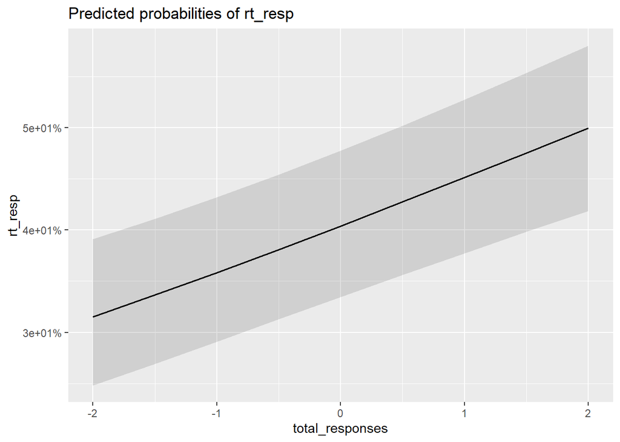

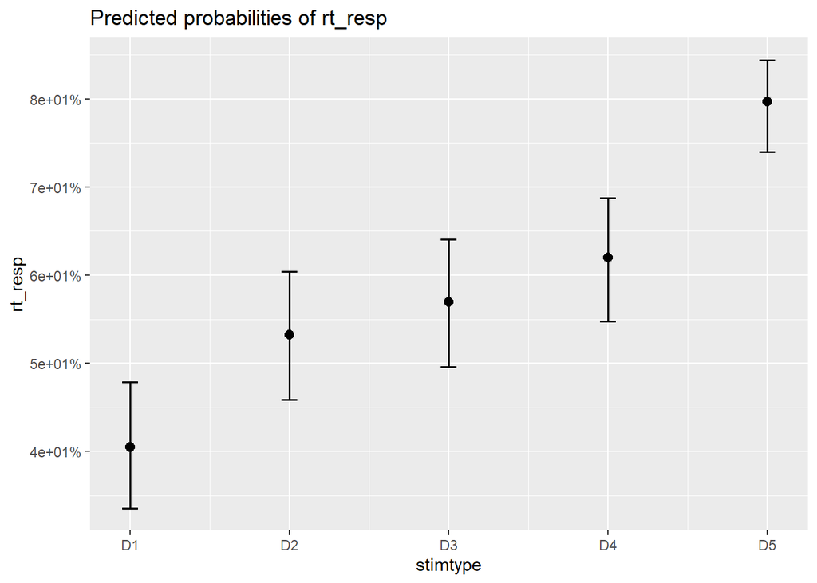

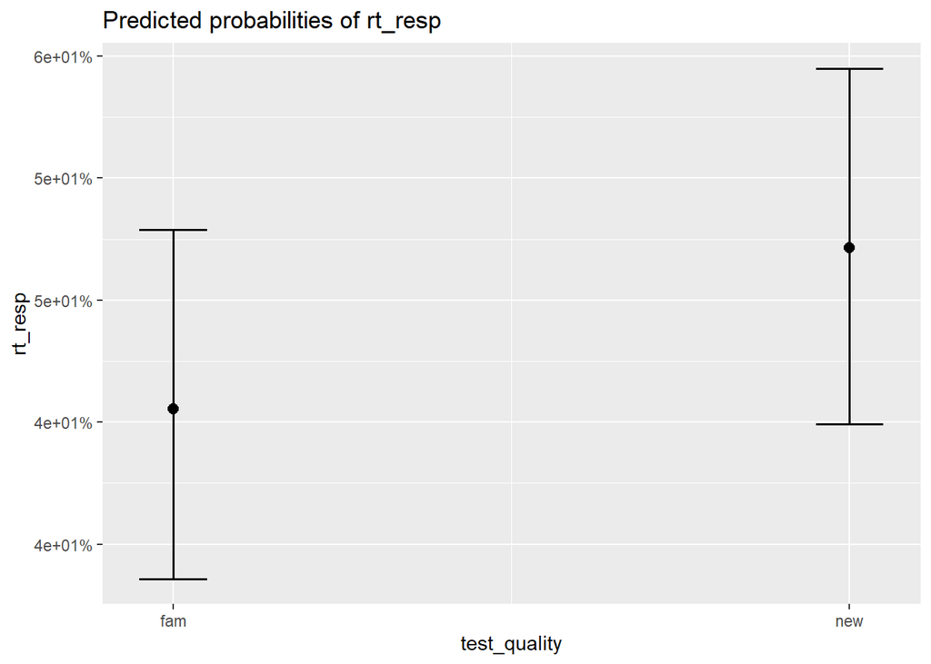

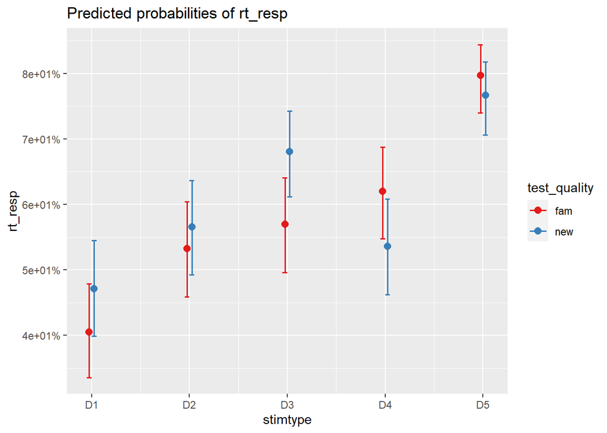

```
## Generalized linear mixed model fit by maximum likelihood (Laplace
##   Approximation) [glmerMod]
##  Family: binomial  ( logit )
## Formula: rt_resp ~ total_responses + DTF * test_quality + (1 | workerId)
##    Data: tdlmm
##
##      AIC      BIC   logLik deviance df.resid
##   4988.3   5026.0  -2488.2   4976.3     3940
##
## Scaled residuals:
##     Min      1Q  Median      3Q     Max
## -4.5839 -0.9494  0.4690  0.8355  1.8783
##
## Random effects:
##  Groups   Name        Variance Std.Dev.
##  workerId (Intercept) 0.4665   0.683
## Number of obs: 3946, groups:  workerId, 42
##
## Fixed effects:
##                     Estimate Std. Error z value Pr(>|z|)
## (Intercept)         -0.49326    0.14003  -3.523 0.000427 ***
## total_responses      0.18713    0.03500   5.346    9e-08 ***
## DTF                  0.12516    0.01208  10.357  < 2e-16 ***
## test_qualitynew      0.39868    0.12924   3.085 0.002037 **
## DTF:test_qualitynew -0.04676    0.01695  -2.759 0.005793 **
## ---
## Signif. codes:  0 '***' 0.001 '**' 0.01 '*' 0.05 '.' 0.1 ' ' 1
##
## Correlation of Fixed Effects:
##             (Intr) ttl_rs DTF    tst_ql
## totl_rspnss -0.024
## DTF         -0.554  0.032
## test_qltynw -0.465  0.011  0.601
## DTF:tst_qlt  0.394  0.002 -0.710 -0.848
## convergence code: 0
## Model failed to converge with max|grad| = 0.00293702 (tol = 0.002, component 1)
```

```
## Package `effects` is not available, but needed for `ggeffect()`. Either install package `effects`, or use `ggpredict()`. Calling `ggpredict()` now.FALSE
## Data were 'prettified'. Consider using `terms="total_responses [all]"` to get smooth plots.
```

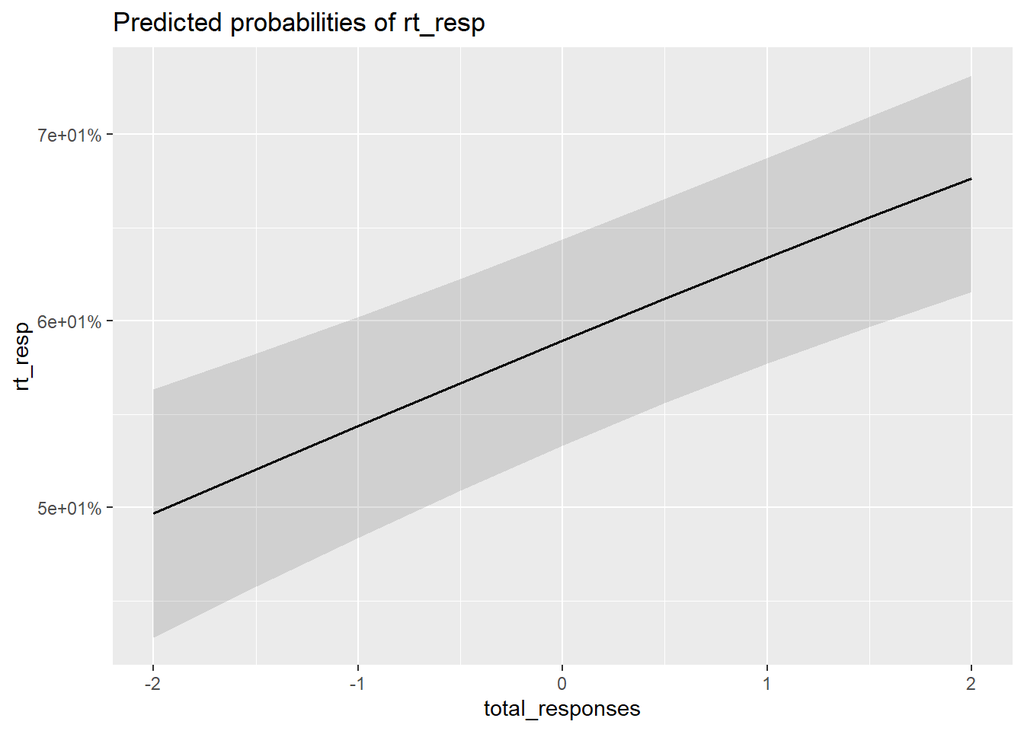

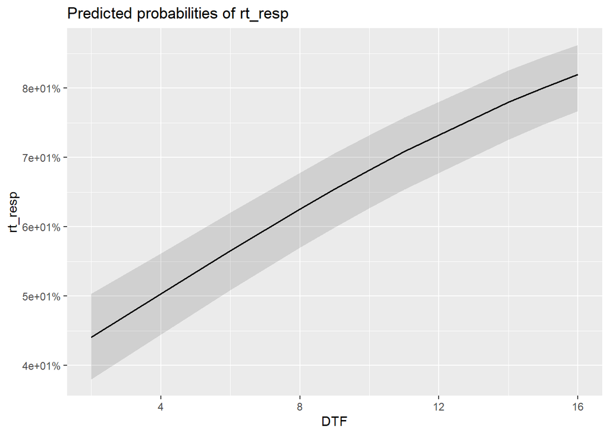

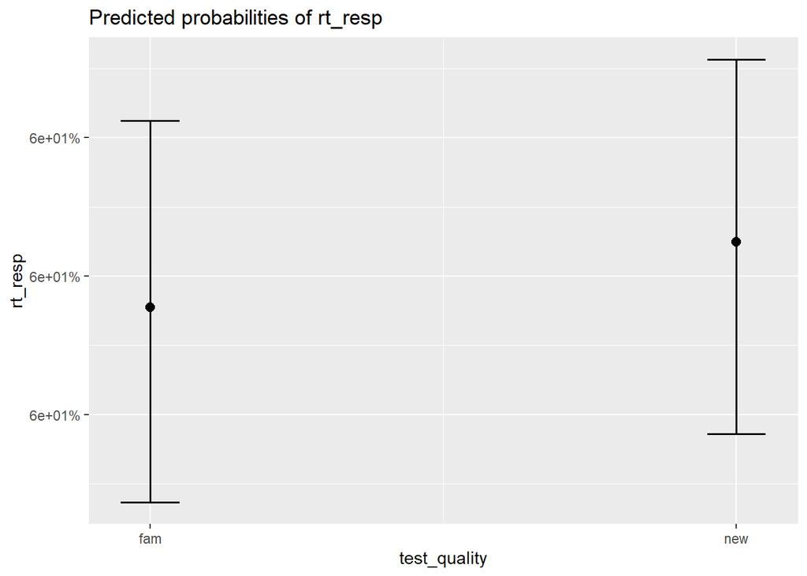

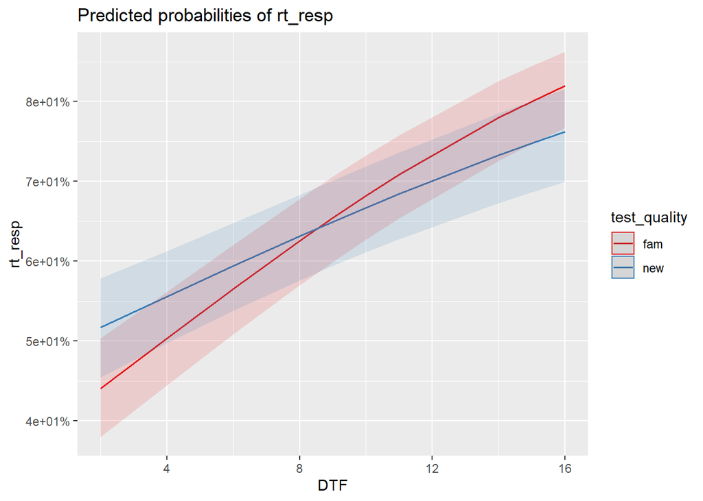

```
## Generalized linear mixed model fit by maximum likelihood (Laplace
##   Approximation) [glmerMod]
##  Family: binomial  ( logit )
## Formula: rt_resp ~ total_responses + DTAF * test_quality + (1 | workerId)
##    Data: tdlmm
##
##      AIC      BIC   logLik deviance df.resid
##   4997.3   5035.0  -2492.6   4985.3     3940
##
## Scaled residuals:
##     Min      1Q  Median      3Q     Max
## -3.9778 -0.9616  0.4793  0.8240  1.7882
##
## Random effects:
##  Groups   Name        Variance Std.Dev.
##  workerId (Intercept) 0.4646   0.6816
## Number of obs: 3946, groups:  workerId, 42
##
## Fixed effects:
##                      Estimate Std. Error z value Pr(>|z|)
## (Intercept)          -3.75106    0.43682  -8.587  < 2e-16 ***
## total_responses       0.18587    0.03499   5.313 1.08e-07 ***
## DTAF                  0.30352    0.03138   9.673  < 2e-16 ***
## test_qualitynew       1.14797    0.59589   1.926   0.0540 .
## DTAF:test_qualitynew -0.08003    0.04397  -1.820   0.0688 .
## ---
## Signif. codes:  0 '***' 0.001 '**' 0.01 '*' 0.05 '.' 0.1 ' ' 1
##
## Correlation of Fixed Effects:
##             (Intr) ttl_rs DTAF   tst_ql
## totl_rspnss -0.026
## DTAF        -0.964  0.024
## test_qltynw -0.688 -0.006  0.704
## DTAF:tst_ql  0.685  0.008 -0.710 -0.993
```

```
## Package `effects` is not available, but needed for `ggeffect()`. Either install package `effects`, or use `ggpredict()`. Calling `ggpredict()` now.FALSE
## Data were 'prettified'. Consider using `terms="total_responses [all]"` to get smooth plots.
```

```
## Data were 'prettified'. Consider using `terms="DTAF [all]"` to get smooth plots.
```

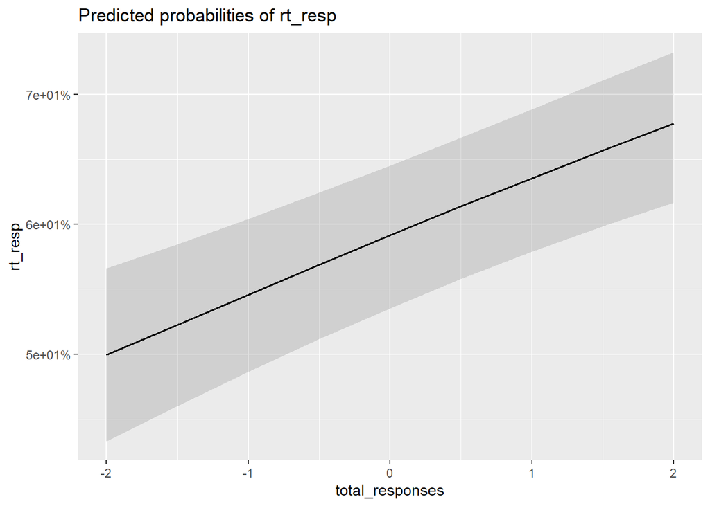

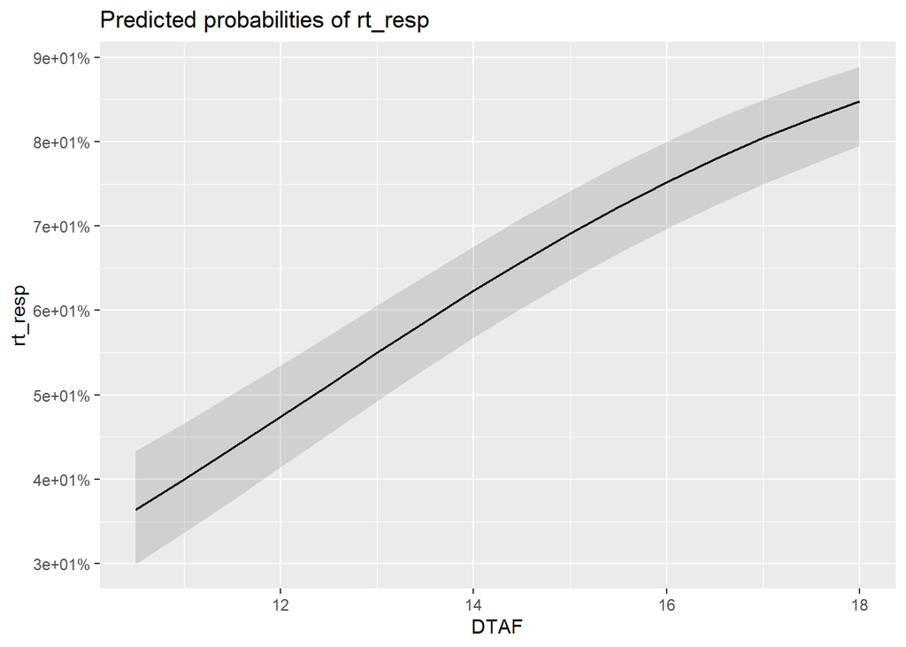

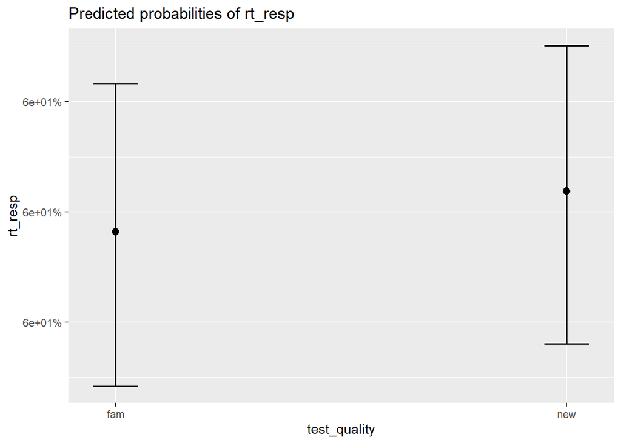